# Optimization

Previous: Output Initialization. Next: Embedding Methods. Up: Index.

I have exposed a lot of options to do with optimization, but I don’t really recommend using most of them, except out of morbid curiosity. Here are the ones that matter:

## `max_iter`

This controls the maximum number of iterations. The default is 1000, which is probably way too high, but it depends on your data set.

Often, the data is in a pretty good shape after 100 iterations, after which it’s just fine tuning, with various clusters very slowly moving away from each other.

For example, let’s run t-SNE on the `iris` data set for 100 iterations:

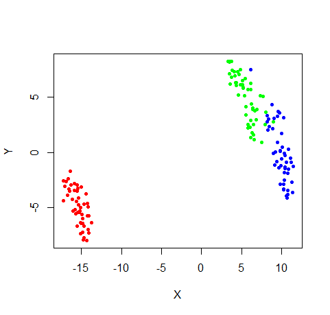

`iris_tsne <- sneer(iris, max_iter = 100)`

And then do it again, but this time let it go for 1000 iterations:

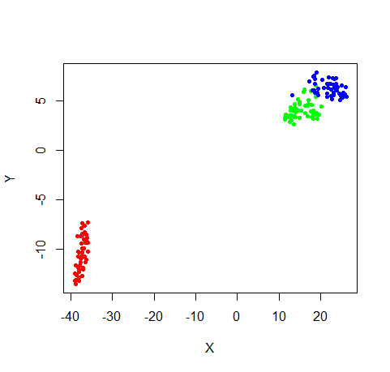

`iris_tsne <- sneer(iris, max_iter = 1000)`

Yes, they look different. But not that different that you would draw qualitatively the wrong conclusions.

If you attempt to quantify the result of your embedding, for example by using some of the methods mentioned in the Analysis section, these can be sensitive to the coordinates. So if you’re comparing different methods, ensure you are not unfairly maligning a method because you didn’t let it converge. But most of the time, embedding methods are used to eyeball a data set, not for quantitative dimensionality reduction, so you probably don’t care. Additionally, a lower error embedding can sometimes look *worse* than a configuration from earlier iterations. The overall structure of the embedding, e.g. the number of relative positons of clusters, appears quite early in the optimization. These clusters then tend to spend the rest of the time increasing their relative distances and growing tighter. You then have to spend more time panning and zooming than you would otherwise. So don’t be afraid to crank down `max_iter`.

## `max_fn`, `max_gr`, `max_fg`

During one iteration, depending on the type of optimizer being used, multiple gradient and function evaluations may be made. As these evaluations take up most of the computational time, you may prefer to restrict the number of these evaluations, rather than the iterations. You can specify any of a maximum number of function evaluations (`max_fn`), gradient evaluations (`max_gr`) or the sum of function and gradient evaluations (`max_fg`).

These parameters only constrain the maximum number of evaluations for the gradient of the error associated with the coordinates. If you are using a “dynamic” kernel optimization, gradient evaluations relative to the kernel parameters do not count towards this total. See Embedding Methods for more on these “dynamic” methods.

## `tol`

Another way to stop the embedding early is to adjust the tolerance parameter, `tol`. If you jump ahead to the Reporting, you’ll see a discussion of the messages logged to the console during the optimization phase. What you should know is that if the value of `rtol` reported in the output ever falls below `tol`, then optimization is considered converged. The default is `1e-5`, which once again errs on the side of caution. It pretty much ensures that if the formatted `cost` or `norm` values in the output log are still changing, it won’t stop early. But once again, you might want to turn that way down for simple visualizations. A `tol` of `0.01` is pretty reasonable:

```r
iris_tsne <- sneer(iris, tol = 0.01) # stops after 200 steps
```

## `opt`

### t-SNE (Delta-Bar-Delta)

Most t-SNE implementations follow the optimization technique given by the [t-SNE paper](http://jmlr.org/papers/v9/vandermaaten08a.html): the direction of optimization is basic gradient descent with a momentum term, and an adaptive step size, which requires setting an initial learning rate, `eta`. This is a variant of the “Delta-Bar-Delta”" method originally used for training neural networks.

This works well for t-SNE, and it’s fast, but in my experience it can cause divergence when a non t-SNE embedding method is used or your input data is not well scaled. For this reason, it’s not the default.

If you want to use it, set the `opt` parameter to `"tsne"` and the `eta` value for the learning rate:

```r
iris_tsne <- sneer(iris, opt = "tsne", eta = 500, scale_type = "matrix")
```

As the above example indicates, you should also scale the input data. See the Preprocessing for your options, but I recommend `scale_type = "matrix"` or `scale_type = "tsne"`.

t-SNE optimization is usually combined with early exaggeration and random initialization. See the Input Initialization and Output Initialization sections for more details, but for an authentic-ish t-SNE experience, run:

```r
iris_tsne <- sneer(iris, opt = "tsne", eta = 500, exaggerate = 4,
                   scale_type = "tsne", exaggerate_off_iter = 100,
                   perplexity = 30, init = "r")
```

For larger datasets (although you almost certainly aren’t using a larger dataset with sneer!) try:

```r
iris_tsne <- sneer(iris, opt = "tsne", eta = 200, exaggerate = 12,
                   scale_type = "tsne", exaggerate_off_iter = 250,
                   perplexity = 50, init = "r")
```

### L-BFGS

The default optimizer uses the limited-memory Broyden-Fletcher-Goldfarb-Shanno (L-BFGS) optimizer and is used in the [JSE paper](http://dx.doi.org/10.1016/j.neucom.2012.12.036).

```r
s1k_tsne <- sneer(s1k, opt = "L-BFGS")
```

### Conjugate Gradient

If you want to try using the conjugate gradient optimization method (which is the method used in the [NeRV](http://www.jmlr.org/papers/v11/venna10a.html) paper, use:

```r
s1k_tsne <- sneer(s1k, opt = "CG")
```

In case you are curious, the specific flavor of CG used is the Polak-Ribiere update with restart (sometimes called ‘PR+’).

### Spectral Directions

The [Spectral Directions](https://arxiv.org/abs/1206.4646) optimizer is specially crafted for certain neighbor embedding functions, including t-SNE. Specifically, using the jargon referenced in the gradients theory page, only methods which use the “pairwise” normalization method work with it.

The Spectral Directions method relies on sparsity for it to be performant, which is something `sneer` doesn’t currently support. You may therefore run into memory problems if you use it with large data sets, but you’re going to run into memory problems with large data sets anyway, so it may not make a massive difference.

```r
s1k_tsne <- sneer(s1k, opt = "SPEC")
```

### Nesterov Momentum

The L-BFGS, CG and Spectral Directions methods are all gradient descent methods that rely on a strong Wolfe line search to make progress. An alternative approach using an adaptive step size and a momentum scheme that emulates the Nesterov Accelerated Gradient (NAG) is also available, which is closer to the original t-SNE optimization method in spirit, while being a bit more robust when using other embedding methods.

A description of the connection between momentum and NAG is given in this deep learning paper. Additionally, it makes use of [adaptive restart](https://arxiv.org/abs/1204.3982).

The step size is by the “bold driver” method, for which you can also use the `eta` parameter to set the initial learning rate.

```r
iris_tsne <- sneer(iris, eta = 10, opt = "nest")
```

This method tends to be a little slower than the `"tsne"` optimization method, but it gives good results for most combinations of scaling, embedding method and data set.

But if in doubt, just use the default L-BFGS optimizer.

## Convergence

Under normal circumstances, the optimizer tracks its progress, and may decide to stop early if not much is happening (i.e. the step size it takes becomes very small). This is designed to save time between the embedding-specific convergence checks sneer does (see the Reporting section for more). Normally, sneer will force the optimizer to restart once if it detects progress has stalled, before calling a halt to proceedings.

Normally, this is what we want, but sometimes we know that things are going to change at some point later in the embedding: e.g. early embedding will turn off or the perplexity is going to change (see Input Initialization), or the embedding method will start optimizing the kernel parameters (see Embedding Methods). Having the entire embedding give up because the optimizer has reached a plateau at this point is undesirable.

When sneer detects that a future iteration will make a change of this sort, it will not stop the embedding early if the optimizer converges. Instead, it will do nothing on each iteration until a change occurs.

You shouldn’t have to worry about this behavior. But it’s worth being aware that if you are using early exaggeration with a optimizer like L-BFGS or CG which use line searches, I suggest turning down the `exaggerate_off_iter` to something between `5` to `10`.

The default value is intended for use with `opt = "tsne"`, which only carries out one gradient evaluation per iteration. Methods using line searches can make multiple gradient evaluations per iteration, and tend to make much larger steps per iteration. This makes it quite easy for the optimizer to converge during the exaggeration stage. If this happens around iteration 5, and the exaggeration doesn’t turn off until iteration 50, then sneer does nothing for 45 iterations. This isn’t that big a deal, unless for some reason you have set the maximum number of iterations to something like 55. In that case, you’d only be getting 5 non-exaggerated iterations, rather than the 50 you’d get if you turn off the exaggeration at a more suitable iteration.

Previous: Output Initialization. Next: Embedding Methods. Up: Index.